# ML Project

jetzgetzlos

21 mai 2017

## Introduction

The goal of your project is to predict the manner in which they did the exercise. This is the “classe” variable in the training set. You may use any of the other variables to predict with. You should create a report describing how you built your model, how you used cross validation, what you think the expected out of sample error is, and why you made the choices you did. Using devices such as Jawbone Up, Nike FuelBand, and Fitbit it is now possible to collect a large amount of data about personal activity relatively inexpensively. These type of devices are part of the quantified self movement - a group of enthusiasts who take measurements about themselves regularly to improve their health, to find patterns in their behavior, or because they are tech geeks. One thing that people regularly do is quantify how much of a particular activity they do, but they rarely quantify how well they do it. In this project, your goal will be to use data from accelerometers on the belt, forearm, arm, and dumbell of 6 participants. They were asked to perform barbell lifts correctly and incorrectly in 5 different ways. More information is available from the website here: http://groupware.les.inf.puc-rio.br/har (see the section on the Weight Lifting Exercise Dataset).

The training data for this project are available here: https://d396qusza40orc.cloudfront.net/predmachlearn/pml-training.csv

The test data are available here: https://d396qusza40orc.cloudfront.net/predmachlearn/pml-testing.csv

## Getting and Clean Data - Exploratory Analysis

```r
training <- read.csv("pml-training.csv", na.strings = c("NA", ""))
testing <- read.csv("pml-testing.csv", na.strings = c("NA", ""))
```

The training dataset has 19622 obs. of 160 variables. The testing dataset gas 20 obs. of 160 variables.

**Cleaning data, step #1** : We can remove the first 7 columns (id, name, timestamp …) which have poorlry relationships with `classe` column. We choose also to ignore columns which were pre-processed or computed : *ie.* column which name begin with *avg, var, max, min, std, kurtosis or skewness* : we want to keep only probe measures.

```r
training <- training[,-c(1:7)]
rm_col <- grep("avg_*|var_*|max_*|min_*|std_*|kurtosis_*|skewness_*|total_*|amplitude*",
               names(training))
training <- training[,-rm_col]
```

**testing NA values** : Check if there are any missing values:

```r
anyNA(training)
```

```
## [1] FALSE
```

It seems Ok.

*The tesing dataset will be processed exactly in the same way to keep the same columns*.

## Data Splitting for cross validation

60% of the data for the training process and 40% for the testing process.

```r
library(caret)
```

```r
set.seed(1805)
inTrain <- createDataPartition(training$classe, p = 0.6, list = FALSE)
train_df <- training[inTrain, ]
test_df <- training[-inTrain, ]
```

## Classification models

We try to classify raws into 5 classes. So, we will try 3 different methods : Simple Tree Prediction, boosting (gbm) and Random Forest (subset and full dataset because of this method which is very time-consuming)

### Simple Tree Prediction (rpart)

```r
modFit_tree <- train(classe ~ ., method="rpart", data =train_df )
print(modFit_tree$finalModel)
```

```
## n= 11776
##
## node), split, n, loss, yval, (yprob)
##       * denotes terminal node
##
##  1) root 11776 8428 A (0.28 0.19 0.17 0.16 0.18)
##    2) roll_belt< 130.5 10766 7426 A (0.31 0.21 0.19 0.18 0.11)
##      4) pitch_forearm< -34.55 948    2 A (1 0.0021 0 0 0) *
##      5) pitch_forearm>=-34.55 9818 7424 A (0.24 0.23 0.21 0.2 0.12)
##       10) magnet_dumbbell_y< 436.5 8290 5951 A (0.28 0.18 0.24 0.19 0.11)
##         20) roll_forearm< 123.5 5134 3056 A (0.4 0.18 0.18 0.17 0.063) *
##         21) roll_forearm>=123.5 3156 2097 C (0.083 0.17 0.34 0.23 0.18) *
##       11) magnet_dumbbell_y>=436.5 1528  744 B (0.036 0.51 0.037 0.24 0.18) *
##    3) roll_belt>=130.5 1010    8 E (0.0079 0 0 0 0.99) *
```

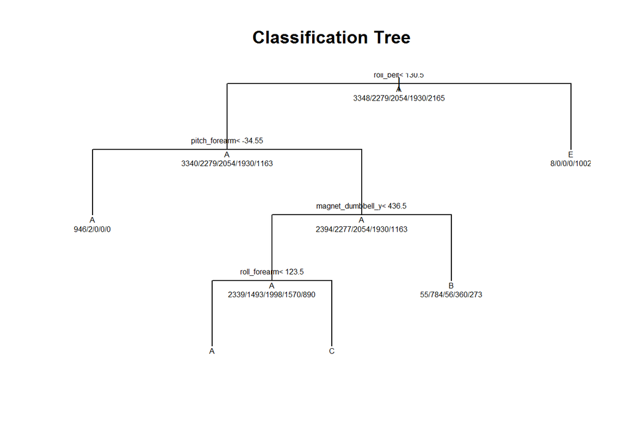

```r
plot(modFit_tree$finalModel, uniform = TRUE,
     main="Classification Tree")
text(modFit_tree$finalModel, use.n=TRUE, all=TRUE, cex=0.5)
```

Testing the model with the testing 40% dataset

```r
confusionMatrix(test_df$classe,predict(modFit_tree, newdata=test_df))$overall
```

```
##       Accuracy          Kappa  AccuracyLower  AccuracyUpper   AccuracyNull
##      0.4917155      0.3354230      0.4805946      0.5028426      0.5220495
## AccuracyPValue  McnemarPValue
##      1.0000000            NaN
```

*The accuracy is very low (<50%)*

### Boosting with tree (bgm)

```r
modFit_gbm <- train(classe ~ ., method="gbm", data =train_df, verbose = F)
print(modFit_gbm$finalModel)
```

```
## A gradient boosted model with multinomial loss function.
## 150 iterations were performed.
## There were 48 predictors of which 41 had non-zero influence.
```

Testing the model with the testing dataset:

```r
confusionMatrix(test_df$classe,predict(modFit_gbm, newdata=test_df))$overall
```

```
##       Accuracy          Kappa  AccuracyLower  AccuracyUpper   AccuracyNull
##   9.583227e-01   9.472652e-01   9.536634e-01   9.626375e-01   2.877900e-01
## AccuracyPValue  McnemarPValue
##   0.000000e+00   9.731358e-12
```

*The accuracy is* : 0.96. It’s quite good.

### Using the model for the testing data set (for the quizz)

```r
predict(modFit_gbm, testing)
```

```
##  [1] B A B A A E D B A A B C B A E E A B B B
## Levels: A B C D E
```

100% passed !

### Random forest

We subset the training data set to reduce the computing time (otherwise it is too long !!)

```r
inTrain2 <- createDataPartition(training$classe, p = 0.2, list = FALSE)
train_df2 <- training[inTrain2, ]
test_df2 <- training[-inTrain2, ]

modFit_rf <- train(classe ~ ., method="rf",data =train_df2, prox = TRUE)
print(modFit_rf$finalModel)
```

```
##
## Call:
##  randomForest(x = x, y = y, mtry = param$mtry, proximity = TRUE)
##                Type of random forest: classification
##                      Number of trees: 500
## No. of variables tried at each split: 25
##
##         OOB estimate of  error rate: 3.11%
## Confusion matrix:
##      A   B   C   D   E class.error
## A 1106   6   2   1   1 0.008960573
## B   23 716  16   4   1 0.057894737
## C    1  17 660   7   0 0.036496350
## D    1   2  17 621   3 0.035714286
## E    0   5   6   9 702 0.027700831
```

Testing the model with the testing dataset :

```r
confusionMatrix(test_df2$classe,predict(modFit_rf, newdata=test_df2))$overall
```

```
##       Accuracy          Kappa  AccuracyLower  AccuracyUpper   AccuracyNull
##   9.727302e-01   9.654931e-01   9.700610e-01   9.752221e-01   2.884358e-01
## AccuracyPValue  McnemarPValue
##   0.000000e+00   4.394148e-20
```

*The accuracy is* 0.97

### Using the model for the testing data set (for the quizz)

```r
predict(modFit_rf, testing)
```

```
##  [1] B A B A A E D D A A B C B A E E A B B B
## Levels: A B C D E
```

### Random forest (with full data set)

The accuracy of the first attempt is quite good but it’s maybe not enough. So, we try with th full data (8 hours of computed time !!)

```r
modFit_rft <- train(classe ~ ., method="rf",data =train_df, prox = TRUE)
print(modFit_rft$finalModel)
```

```
##
## Call:
##  randomForest(x = x, y = y, mtry = param$mtry, proximity = TRUE)
##                Type of random forest: classification
##                      Number of trees: 500
## No. of variables tried at each split: 25
##
##         OOB estimate of  error rate: 0.88%
## Confusion matrix:
##      A    B    C    D    E class.error
## A 3343    4    1    0    0 0.001493429
## B   22 2249    7    1    0 0.013163668
## C    0   15 2031    8    0 0.011197663
## D    1    2   27 1899    1 0.016062176
## E    0    1    5    9 2150 0.006928406
```

Testing the model with the testing dataset :

```r
confusionMatrix(test_df$classe,predict(modFit_rft, newdata=test_df))$overall
```

```
##       Accuracy          Kappa  AccuracyLower  AccuracyUpper   AccuracyNull
##      0.9926077      0.9906492      0.9904541      0.9943821      0.2848585
## AccuracyPValue  McnemarPValue
##      0.0000000            NaN
```

The accuracy is 0.99. **It’s very good !**

## Conclusion

The random forest algorithm, computed with the whole data set, appears to be a very good classification method for this use case (accelerometers measurements). Accuracy is very good. Nevertheless, this method is hightly time-consuming.